# Human Activity Recognition

James Fielding

June 17, 2015

## Abstract

In the last few years, Human Activity Recognition (HAR) has emerged as a key research area given the increased availability and declining costs of devices such as Jawbone Up, Nike FuelBand, and Fitbit. It is now possible to collect a large amount of data about personal activity for very little cost. There are many potential applications for HAR including: elderly monitoring, life log systems for monitoring energy expenditure and for supporting weight-loss programs, and digital assistants for weight lifting exercises.

This analysis used data previously collected from accelerometers on the belt, forearm, arm, and dumbbell of 6 subjects when performing barbell lifts in 5 different ways (sitting-down, standing-up, standing, walking, and sitting). The goal was to created a model that predicted the correct position of a subject for a given set of measurements.

Upon completion, this analysis produced a predictive model that was accurate (99%), as well as a submission output for the Practical Machine Learning course.

## Data Retrieval

The data was available via download and was obtained as follows:

```r
suppressMessages(library(dplyr))

get.data <- function (file.name, file.url) {
    #Check if files exists, and download if necessary

    setInternet2(use = TRUE) #necessary for https in Windows OS

    if (!file.exists(file.name)) {
        download.file(
            file.url, destfile = file.name, method = "auto", mode = "wb"
        )
    }

pml.asis <- c(3:5,7:13,15:16,18:25,27:88,90:91,
              93:100,102:126,128:129,131:138,140:159)

    tbl_df(read.csv(file.name,na.strings=c("", "NA", "NULL", "#DIV/0!"),
                    as.is = pml.asis))
}

training.url <- "https://d396qusza40orc.cloudfront.net/predmachlearn/pml-training.csv"
pml.train <- get.data("pml-training.csv",training.url)
```

By default, R factored many of the variables. To override this default behavior, a `as.is` vector was added. Initially there were 19622 observations of 160 variables in the training dataset, including the `classe` variable that denotes the manner in which the observation subject did the observed exercise.

## Data Preprocessing

```r
pre.process <- function (dataset) {
  dataset <- dataset[, -c(1:7)]
  dataset <- dataset[,colSums(is.na(dataset)) <= 0.95 *  nrow(dataset)]
  dataset <- dataset[complete.cases(dataset),]
  return(dataset)
}

pml.train <- pre.process(pml.train)
```

Finally, the data was divided into training and testing sets:

```r
suppressMessages(library(caret))

set.seed(12345)
trainIndex <- createDataPartition(pml.train$classe, p=0.70, list=FALSE)
training<- pml.train[trainIndex,]
testing<- pml.train[-trainIndex,]
```

## Modeling

Random Forest was chosen as the method to build the prediction mode, given the large number of variables with incremental differences.

An attempt to fit a model was done using the `train` function of the carat package. Unfortunately, this method was eventually terminated because of the excessive amount of processing time without completion.

```r
controlObject <- trainControl(verboseIter = TRUE, method = "repeatedcv",
                           number = 10, ## repeated ten times
                           repeats = 10)
modelFitCar <- train(classe~ .,data=training , method = "rf",
                     tuneLength = 10, ntrees = 500, importance = TRUE,
                     prox=TRUE, trControl = controlObject)
```

The `randomForest` function was initially used with `proximity = TRUE` to produce a 1.4 Gb model with 99.2% accuracy. Given the time and memory required to utilize this model, a second model was produced using `proximity = FALSE` to produce the final model:

```r
suppressMessages(library(randomForest))
modelFitRf <-randomForest(classe ~., data = training, ntree=500,
                          importance = TRUE, proximity = FALSE)
modelFitRf
```

```
##
## Call:
##  randomForest(formula = classe ~ ., data = training, ntree = 500,      importance = TRUE, proximity = FALSE)
##                Type of random forest: classification
##                      Number of trees: 500
## No. of variables tried at each split: 7
##
##         OOB estimate of  error rate: 0.58%
## Confusion matrix:
##      A    B    C    D    E class.error
## A 3901    2    1    0    2 0.001280082
## B   13 2641    4    0    0 0.006395786
## C    0   17 2372    7    0 0.010016694
## D    0    0   23 2227    2 0.011101243
## E    0    0    1    7 2517 0.003168317
```

The model produced was a very reasonable 27.5 Mb. The out-of-bag (OOB) error of 0.58% for the model seemed very promising. As such, the model’s error vs. number of trees was graphed:

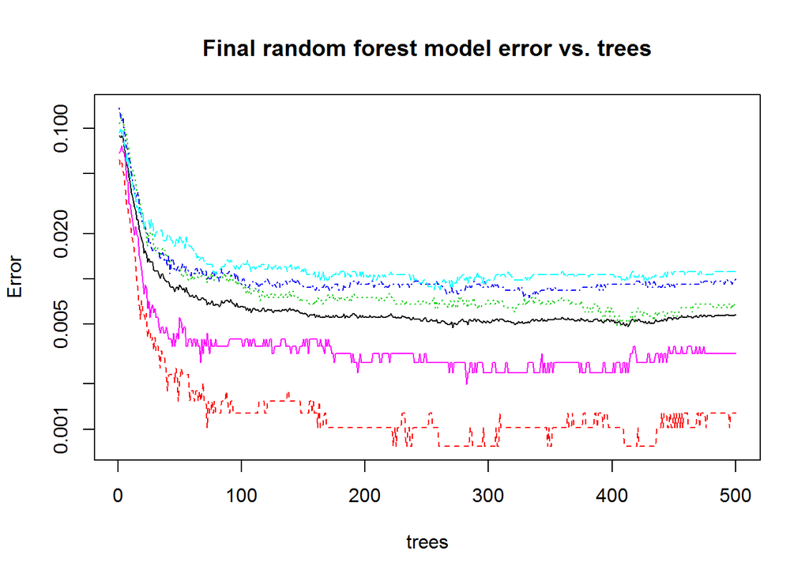

```r
with(modelFitRf, plot(modelFitRf, log = "y", main = "Final random forest model error vs. trees"))
```

As a result of the plot above, a second model using `ntree=200` was created using the `randomForest` function. Although it was only 13.4 Mb is size, it was determined to be slightly less accurate (0.1%). As such, the first model was used as the final model, given that it was already produced.

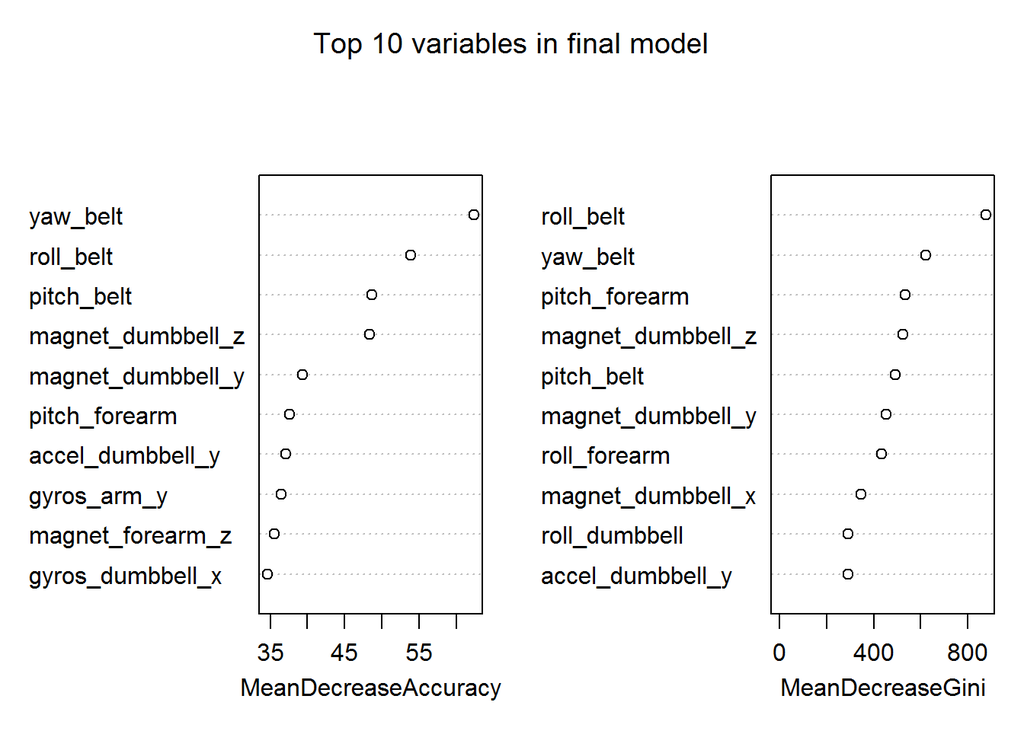

```r
varImpPlot(modelFitRf, n.var = 10, main = "Top 10 variables in final model" )
```

The variable importance plot above showed that the yaw_belt measurements were most important for accuracy, whereas the roll_belt had the largest effect on the homogeneity of the nodes and leaves in the resulting random forest (Gini coefficient).

The hope was for the model to achieve at least a 95% prediction accuracy. The model was used to predict the testing set and the cross-validation accuracy was calculated as follows:

```r
prediction <- predict(modelFitRf, testing)
testing$correctPred <- prediction == testing$classe
accuracy <- sum(testing$correctPred)/nrow(testing)
accuracy
```

```
## [1] 0.9932031
```

With an accuracy of 99.32% on the testing set (and an error rate of 0.68%), the model met the requirements to proceed.

## Predictions

The submission dataset was obtained:

```r
testing.url <- "https://d396qusza40orc.cloudfront.net/predmachlearn/pml-testing.csv"
pml.test <- get.data("pml-testing.csv",testing.url)
```

Finally, the submission predictions were established:

```r
submission <- predict(modelFitRf, pml.test)
submission
```

```
##  1  2  3  4  5  6  7  8  9 10 11 12 13 14 15 16 17 18 19 20
##  B  A  B  A  A  E  D  B  A  A  B  C  B  A  E  E  A  B  B  B
## Levels: A B C D E
```

## Conclusion

The model obtained ended up being highly successful for submission purposes. Going forward, it would be interesting to properly tune the carat `rf` method to reduce processing times and allow the train function to be compared with the `randomForest` function used in the submission, for accuracy and time to execute.

## References

Ugulino, W.; Cardador, D.; Vega, K.; Velloso, E.; Milidiu, R.; Fuks, H. Wearable Computing: Accelerometers’ Data Classification of Body Postures and Movements. Proceedings of 21st Brazilian Symposium on Artificial Intelligence. Advances in Artificial Intelligence - SBIA 2012. In: Lecture Notes in Computer Science. , pp. 52-61. Curitiba, PR: Springer Berlin / Heidelberg, 2012. ISBN 978-3-642-34458-9. DOI: 10.1007/978-3-642-34459-6_6.